# Lab 11: Basic String Manipulation

Stat 133, Spring 2022

### Learning Objectives

> - String manipulation
> - Base R functions for strings
> - String manipulation

### General Instructions

- Write your descriptions, explanations, and code in an `Rmd` (R markdown) file.
- Name this file as `lab11-first-last.Rmd`, where `first` and `last` are your first and last names (e.g. `lab11-gaston-sanchez.Rmd`).
- Knit your `Rmd` file as an html document (default option).
- Submit your `Rmd` and `html` files to bCourses, in the corresponding lab assignment.

```r
library(tidyverse)
```

## Basics of String Manipulation

In this first part of the lab, you will be using the row names of the data frame `USArrests` (this data comes already in R):

```r
head(USArrests)
```

```
##            Murder Assault UrbanPop Rape
## Alabama      13.2     236       58 21.2
## Alaska       10.0     263       48 44.5
## Arizona       8.1     294       80 31.0
## Arkansas      8.8     190       50 19.5
## California    9.0     276       91 40.6
## Colorado      7.9     204       78 38.7
```

```r
states <- rownames(USArrests)
head(states)
```

```
## [1] "Alabama"    "Alaska"     "Arizona"    "Arkansas"   "California"
## [6] "Colorado"
```

Here are some functions that you may need to use in this lab:

- `nchar()`
- `tolower()`
- `toupper()`
- `casefold()`
- `paste()`
- `paste0()`
- `substr()`

## 1) Number of characters

The function `nchar()` allows you to count the number of characters in a string. For example:

```r
nchar(c("Concepts", "in", "computing", "with", "data"))
```

```
## [1] 8 2 9 4 4
```

### 1.1) Your Turn: `nchar()`

Use `nchar()` on `states` to get the number of characters of each state:

```r
nchar(states)
```

```
##  [1]  7  6  7  8 10  8 11  8  7  7  6  5  8  7  4  6  8  9  5  8 13  8  9 11  8
## [26]  7  8  6 13 10 10  8 14 12  4  8  6 12 12 14 12  9  5  4  7  8 10 13  9  7
```

## 2) Case folding

There are 3 functions to do case-folding: `tolower()`, `toupper()`, and `casefold()`.

### 2.1) Your Turn: case folding

Apply each function on `states` to see what happens

```r
tolower(states)
```

```
##  [1] "alabama"        "alaska"         "arizona"        "arkansas"
##  [5] "california"     "colorado"       "connecticut"    "delaware"
##  [9] "florida"        "georgia"        "hawaii"         "idaho"
## [13] "illinois"       "indiana"        "iowa"           "kansas"
## [17] "kentucky"       "louisiana"      "maine"          "maryland"
## [21] "massachusetts"  "michigan"       "minnesota"      "mississippi"
## [25] "missouri"       "montana"        "nebraska"       "nevada"
## [29] "new hampshire"  "new jersey"     "new mexico"     "new york"
## [33] "north carolina" "north dakota"   "ohio"           "oklahoma"
## [37] "oregon"         "pennsylvania"   "rhode island"   "south carolina"
## [41] "south dakota"   "tennessee"      "texas"          "utah"
## [45] "vermont"        "virginia"       "washington"     "west virginia"
## [49] "wisconsin"      "wyoming"
```

```r
toupper(states)
```

```
##  [1] "ALABAMA"        "ALASKA"         "ARIZONA"        "ARKANSAS"
##  [5] "CALIFORNIA"     "COLORADO"       "CONNECTICUT"    "DELAWARE"
##  [9] "FLORIDA"        "GEORGIA"        "HAWAII"         "IDAHO"
## [13] "ILLINOIS"       "INDIANA"        "IOWA"           "KANSAS"
## [17] "KENTUCKY"       "LOUISIANA"      "MAINE"          "MARYLAND"
## [21] "MASSACHUSETTS"  "MICHIGAN"       "MINNESOTA"      "MISSISSIPPI"
## [25] "MISSOURI"       "MONTANA"        "NEBRASKA"       "NEVADA"
## [29] "NEW HAMPSHIRE"  "NEW JERSEY"     "NEW MEXICO"     "NEW YORK"
## [33] "NORTH CAROLINA" "NORTH DAKOTA"   "OHIO"           "OKLAHOMA"
## [37] "OREGON"         "PENNSYLVANIA"   "RHODE ISLAND"   "SOUTH CAROLINA"
## [41] "SOUTH DAKOTA"   "TENNESSEE"      "TEXAS"          "UTAH"
## [45] "VERMONT"        "VIRGINIA"       "WASHINGTON"     "WEST VIRGINIA"
## [49] "WISCONSIN"      "WYOMING"
```

```r
casefold(states)
```

```
##  [1] "alabama"        "alaska"         "arizona"        "arkansas"
##  [5] "california"     "colorado"       "connecticut"    "delaware"
##  [9] "florida"        "georgia"        "hawaii"         "idaho"
## [13] "illinois"       "indiana"        "iowa"           "kansas"
## [17] "kentucky"       "louisiana"      "maine"          "maryland"
## [21] "massachusetts"  "michigan"       "minnesota"      "mississippi"
## [25] "missouri"       "montana"        "nebraska"       "nevada"
## [29] "new hampshire"  "new jersey"     "new mexico"     "new york"
## [33] "north carolina" "north dakota"   "ohio"           "oklahoma"
## [37] "oregon"         "pennsylvania"   "rhode island"   "south carolina"
## [41] "south dakota"   "tennessee"      "texas"          "utah"
## [45] "vermont"        "virginia"       "washington"     "west virginia"
## [49] "wisconsin"      "wyoming"
```

## 3) Length of State Names

In 1.1) you used `nchar()` to count the number of characters in each state name:

```r
# number of charcaters
num_chars <- nchar(states)
```

### 3.1) Your Turn: frequencies

Use the vector `num_chars` to obtain a frequency table called `char_freqs`, and then plot the frequencies with a bar chart. The function `table()` is your friend.

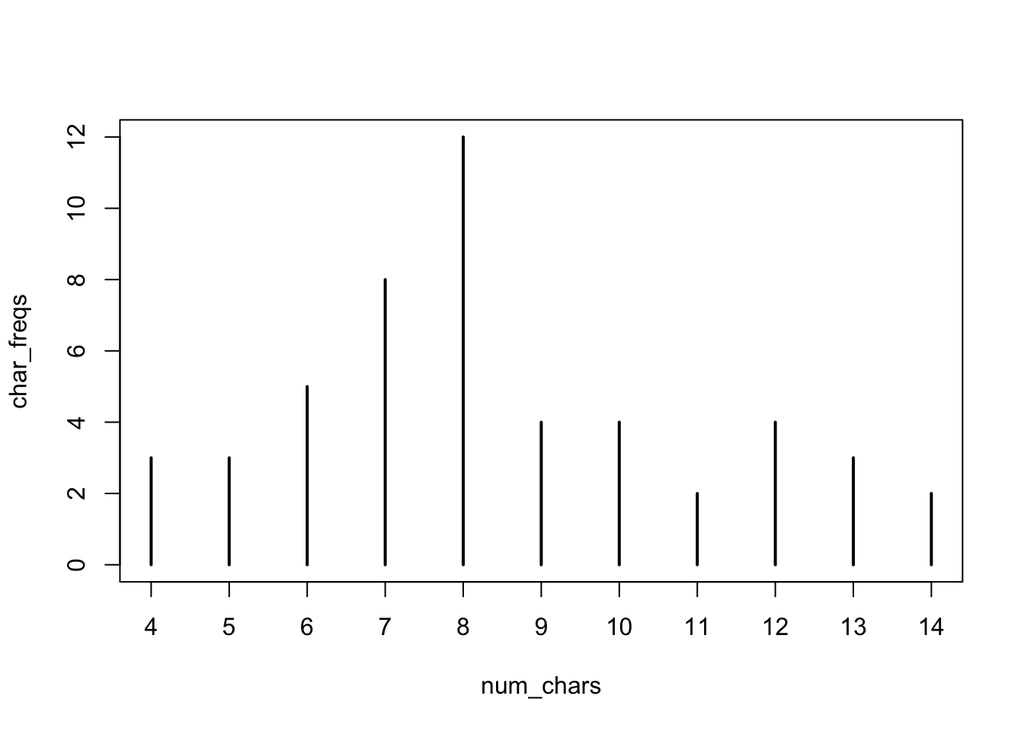

```r
char_freqs <- table(num_chars)
plot(char_freqs)
```

## 4) Pasting strings

R provides the `paste()` function. This function allows you to **paste** (i.e. append, concatenate) character vectors separated by a blank space:

```r
paste('Pumpkin', 'Pie')
```

```
## [1] "Pumpkin Pie"
```

You can give it any number of input vectors

```r
paste('a', 'b', 'c', 'd', 'e')
```

```
## [1] "a b c d e"
```

You can change the separator with `sep`

```r
paste('a', 'b', 'c', 'd', 'e', sep = '-')
```

```
## [1] "a-b-c-d-e"
```

`paste()` is vectorized:

```r
paste('a', 1:5, sep = '.')
```

```
## [1] "a.1" "a.2" "a.3" "a.4" "a.5"
```

There’s a special wrapper around `paste()` called `paste0()` which is equivalent to `paste(..., sep = "")`

```r
# paste0() -vs- paste(..., sep = "")
paste0('Pumpkin', 'Pie')
```

```
## [1] "PumpkinPie"
```

```r
paste('Pumpkin', 'Pie', sep = '')
```

```
## [1] "PumpkinPie"
```

```r
# paste0() is also vectorized
paste0('a', 1:5)
```

```
## [1] "a1" "a2" "a3" "a4" "a5"
```

### 4.1) Your Turn: `paste()`

Use `paste()` to form a new vector with the first five states and their number of characters like this:

`"Alabama = 7" "Alaska = 6" "Arizona = 7" "Arkansas = 8" "California = 10"`

```r
paste(states, num_chars, sep =" = ")[1:5]
```

```
## [1] "Alabama = 7"     "Alaska = 6"      "Arizona = 7"     "Arkansas = 8"
## [5] "California = 10"
```

### 4.2) Your Turn: `paste()` with `collapse`

Now use `paste()`’s argument `collapse = ''` to *collapse* the first five states like this:

`"AlabamaAlaskaArizonaArkansasCalifornia"`

```r
paste(states[1:5], collapse = "")
```

```
## [1] "AlabamaAlaskaArizonaArkansasCalifornia"
```

### 5) Substrings

R provides the function `substr()` to extract substrings in a character vector:

```r
# extract first 3 characters
substr('Berkeley', start = 1, stop = 3)
```

```
## [1] "Ber"
```

### 5.1) Your Turn: `substr()`

1. Use `substr()` to shorten the state names using the first 3-letters:

```r
substr(states, start = 1, stop = 3)
```

```
##  [1] "Ala" "Ala" "Ari" "Ark" "Cal" "Col" "Con" "Del" "Flo" "Geo" "Haw" "Ida"
## [13] "Ill" "Ind" "Iow" "Kan" "Ken" "Lou" "Mai" "Mar" "Mas" "Mic" "Min" "Mis"
## [25] "Mis" "Mon" "Neb" "Nev" "New" "New" "New" "New" "Nor" "Nor" "Ohi" "Okl"
## [37] "Ore" "Pen" "Rho" "Sou" "Sou" "Ten" "Tex" "Uta" "Ver" "Vir" "Was" "Wes"
## [49] "Wis" "Wyo"
```

2. Use `substr()` to shorten the state names using the last 3-letters:

```r
substr(states, start = num_chars - 2, stop = num_chars)
```

```
##  [1] "ama" "ska" "ona" "sas" "nia" "ado" "cut" "are" "ida" "gia" "aii" "aho"
## [13] "ois" "ana" "owa" "sas" "cky" "ana" "ine" "and" "tts" "gan" "ota" "ppi"
## [25] "uri" "ana" "ska" "ada" "ire" "sey" "ico" "ork" "ina" "ota" "hio" "oma"
## [37] "gon" "nia" "and" "ina" "ota" "see" "xas" "tah" "ont" "nia" "ton" "nia"
## [49] "sin" "ing"
```

3. How would you shorten the state names using the first letter and the last 3-letters? For instance: `"Aama"` `"Aska"` `"Aona"` `"Asas"` etc.

```r
paste(substr(states, 1, 1), substr(states, num_chars - 2, stop= num_chars), sep = "")
```

```
##  [1] "Aama" "Aska" "Aona" "Asas" "Cnia" "Cado" "Ccut" "Dare" "Fida" "Ggia"
## [11] "Haii" "Iaho" "Iois" "Iana" "Iowa" "Ksas" "Kcky" "Lana" "Mine" "Mand"
## [21] "Mtts" "Mgan" "Mota" "Mppi" "Muri" "Mana" "Nska" "Nada" "Nire" "Nsey"
## [31] "Nico" "Nork" "Nina" "Nota" "Ohio" "Ooma" "Ogon" "Pnia" "Rand" "Sina"
## [41] "Sota" "Tsee" "Txas" "Utah" "Vont" "Vnia" "Wton" "Wnia" "Wsin" "Wing"
```

## 6) Challenge

We already obtained a frequency table `char_freqs` with the counts of state names by number of characters. You can use those frequencies to get those state-names with 4-characters or 10-characters:

```r
# 4-char states
states[num_chars == 4]
```

```
## [1] "Iowa" "Ohio" "Utah"
```

```r
# 10-char states
states[num_chars == 10]
```

```
## [1] "California" "New Jersey" "New Mexico" "Washington"
```

You can use `paste()` to join the 4-character states in one single string (i.e. *collapsing*) like this—separated by a comma and space—:

```r
# collapse 4-char states
paste(states[num_chars == 4], collapse = ", ")
```

```
## [1] "Iowa, Ohio, Utah"
```

### 6.1) Your Turn: list `states_list`

Write code (using a for-loop) to obtain a list `states_list` containing the collapsed names by number of characters. If the number of characters is an even number, then the state names should be in capital letters. Otherwise, they should be in lower case letters.

Each list element of `states_list` must be named with the number of characters, followed by a dash, followed by the word `chars`: e.g. `'4-chars'`, `'5-chars'`, etc. In total, `states_list` should have the same length as `char_freqs`.

Here’s what `states_list` should look like for the first three elements:

```
$`4-chars`
[1] "IOWA, OHIO, UTAH"

$`5-chars`
[1] "idaho, maine, texas"

$`6-chars`
[1] "ALASKA, HAWAII, KANSAS, NEVADA, OREGON"
```

```r
states_list <- list()
for (i in as.numeric(names(char_freqs))) {
  if (i %% 2 == 0) {
    states_list [[paste(i, 'chars', sep = "-")]] <- toupper(paste(states[num_chars == i], collapse = ", ")) }
  else {
    states_list [[paste(i, 'chars', sep = "-")]] <- tolower(paste(states[num_chars == i], collapse = ", "))
  }
}

states_list
```

```
## $`4-chars`
## [1] "IOWA, OHIO, UTAH"
##
## $`5-chars`
## [1] "idaho, maine, texas"
##
## $`6-chars`
## [1] "ALASKA, HAWAII, KANSAS, NEVADA, OREGON"
##
## $`7-chars`
## [1] "alabama, arizona, florida, georgia, indiana, montana, vermont, wyoming"
##
## $`8-chars`
## [1] "ARKANSAS, COLORADO, DELAWARE, ILLINOIS, KENTUCKY, MARYLAND, MICHIGAN, MISSOURI, NEBRASKA, NEW YORK, OKLAHOMA, VIRGINIA"
##
## $`9-chars`
## [1] "louisiana, minnesota, tennessee, wisconsin"
##
## $`10-chars`
## [1] "CALIFORNIA, NEW JERSEY, NEW MEXICO, WASHINGTON"
##
## $`11-chars`
## [1] "connecticut, mississippi"
##
## $`12-chars`
## [1] "NORTH DAKOTA, PENNSYLVANIA, RHODE ISLAND, SOUTH DAKOTA"
##
## $`13-chars`
## [1] "massachusetts, new hampshire, west virginia"
##
## $`14-chars`
## [1] "NORTH CAROLINA, SOUTH CAROLINA"
```

## 7) Names of files

Imagine that you need to generate the names of 10 data `.csv` files. All the files have the same prefix name but each of them has a different number: `file1.csv`, `file2.csv`, … , `file10.csv`.

### 7.1) Your Turn

How can you generate a character vector with these names in R? Use `paste()`, or `paste0()`, to create a character vector with the names of those files.

1. Use `paste()` to create a character vector with the names of those files.

```r
paste("file", 1:10, ".csv", sep ="")
```

```
##  [1] "file1.csv"  "file2.csv"  "file3.csv"  "file4.csv"  "file5.csv"
##  [6] "file6.csv"  "file7.csv"  "file8.csv"  "file9.csv"  "file10.csv"
```

2. Now use `paste0()` to create the same vector.

```r
file_vec <- paste0("file", 1:10, ".csv")
```

### 7.2) Your Turn

Now imagine that you need to rename the characters `file` into `dataset`. In other words, you want the vector of file names to look like this: `dataset1.csv`, `dataset2.csv`, … , `dataset10.csv`. Find out how to use `gsub()`, so that it takes the previous vector of file names it returns a vector of renamed elements:

```r
gsub("file", "dataset", file_vec)
```

```
##  [1] "dataset1.csv"  "dataset2.csv"  "dataset3.csv"  "dataset4.csv"
##  [5] "dataset5.csv"  "dataset6.csv"  "dataset7.csv"  "dataset8.csv"
##  [9] "dataset9.csv"  "dataset10.csv"
```

## 8) Converting from Fahrenheit Degrees

Here are four functions that convert from Fahrenheit degrees to other temperature scales:

```r
to_celsius <- function(x = 1) {
  (x - 32) * (5/9)
}

to_kelvin <- function(x = 1) {
  (x + 459.67) * (5/9)
}

to_reaumur <- function(x = 1) {
  (x - 32) * (4/9)
}

to_rankine <- function(x = 1) {
  x + 459.67
}
```

We can use the previous functions to create a more general function `temp_convert()`:

```r
temp_convert <- function(x = 1, to = "celsius") {
  switch(to,
         "celsius" = to_celsius(x),
         "kelvin" = # fill in the blank,
         "reaumur" = # fill in the blank,
         "rankine" = # fill in the blank)
}

temp_convert(30, 'celsius')
```

`temp_convert()` works fine when the argument `to = 'celsius'`. But what happens if you try `temp_convert(30, 'Celsius')` or `temp_convert(30, 'CELSIUS')`?

### 8.1) Your Turn: `temp_convert()`

Rewrite `temp_convert()` such that the argument `to` can be given in upper or lower case letters. For instance, the following three calls should be equivalent:

- `temp_convert(30, 'celsius')`
- `temp_convert(30, 'Celsius')`
- `temp_convert(30, 'CELSIUS')`

```r
temp_convert <- function(x = 1, to = "celsius") {
  switch(tolower(to),
         "celsius" = to_celsius(x),
         "kelvin" = to_kelvin(x),
         "reaumur" = to_reaumur(x),
         "rankine" = to_rankine(x))
}
```